# Risk Factor Analysis

## Outcome Variable

**Outcome Variable:** wasted

## Predictor Variables

**Intervention Variable:** birthlen

**Adjustment Set:**

unadjusted

## Stratifying Variables

The analysis was stratified on these variable(s):

- agecat
- studyid
- country

## Data Summary

| agecat | studyid | country | birthlen | wasted | n_cell | n |
| --- | --- | --- | --- | --- | --- | --- |
| Birth | ki0047075b-MAL-ED | BANGLADESH | >=50 cm | 0 | 19 | 241 |
| Birth | ki0047075b-MAL-ED | BANGLADESH | >=50 cm | 1 | 10 | 241 |
| Birth | ki0047075b-MAL-ED | BANGLADESH | <48 cm | 0 | 110 | 241 |
| Birth | ki0047075b-MAL-ED | BANGLADESH | <48 cm | 1 | 18 | 241 |
| Birth | ki0047075b-MAL-ED | BANGLADESH | [48-50) cm | 0 | 72 | 241 |
| Birth | ki0047075b-MAL-ED | BANGLADESH | [48-50) cm | 1 | 12 | 241 |
| Birth | ki0047075b-MAL-ED | BRAZIL | >=50 cm | 0 | 31 | 183 |
| Birth | ki0047075b-MAL-ED | BRAZIL | >=50 cm | 1 | 3 | 183 |
| Birth | ki0047075b-MAL-ED | BRAZIL | <48 cm | 0 | 72 | 183 |
| Birth | ki0047075b-MAL-ED | BRAZIL | <48 cm | 1 | 1 | 183 |
| Birth | ki0047075b-MAL-ED | BRAZIL | [48-50) cm | 0 | 74 | 183 |
| Birth | ki0047075b-MAL-ED | BRAZIL | [48-50) cm | 1 | 2 | 183 |
| Birth | ki0047075b-MAL-ED | INDIA | >=50 cm | 0 | 22 | 203 |
| Birth | ki0047075b-MAL-ED | INDIA | >=50 cm | 1 | 3 | 203 |
| Birth | ki0047075b-MAL-ED | INDIA | <48 cm | 0 | 87 | 203 |
| Birth | ki0047075b-MAL-ED | INDIA | <48 cm | 1 | 17 | 203 |
| Birth | ki0047075b-MAL-ED | INDIA | [48-50) cm | 0 | 61 | 203 |
| Birth | ki0047075b-MAL-ED | INDIA | [48-50) cm | 1 | 13 | 203 |
| Birth | ki0047075b-MAL-ED | NEPAL | >=50 cm | 0 | 33 | 168 |
| Birth | ki0047075b-MAL-ED | NEPAL | >=50 cm | 1 | 5 | 168 |
| Birth | ki0047075b-MAL-ED | NEPAL | <48 cm | 0 | 53 | 168 |
| Birth | ki0047075b-MAL-ED | NEPAL | <48 cm | 1 | 11 | 168 |
| Birth | ki0047075b-MAL-ED | NEPAL | [48-50) cm | 0 | 62 | 168 |
| Birth | ki0047075b-MAL-ED | NEPAL | [48-50) cm | 1 | 4 | 168 |
| Birth | ki0047075b-MAL-ED | PERU | >=50 cm | 0 | 33 | 279 |
| Birth | ki0047075b-MAL-ED | PERU | >=50 cm | 1 | 1 | 279 |
| Birth | ki0047075b-MAL-ED | PERU | <48 cm | 0 | 131 | 279 |
| Birth | ki0047075b-MAL-ED | PERU | <48 cm | 1 | 3 | 279 |
| Birth | ki0047075b-MAL-ED | PERU | [48-50) cm | 0 | 109 | 279 |
| Birth | ki0047075b-MAL-ED | PERU | [48-50) cm | 1 | 2 | 279 |

[output cut: 432 more lines]

The following strata were considered:

- agecat: 24 months, studyid: ki0047075b-MAL-ED, country: BANGLADESH
- agecat: 24 months, studyid: ki0047075b-MAL-ED, country: BRAZIL
- agecat: 24 months, studyid: ki0047075b-MAL-ED, country: INDIA
- agecat: 24 months, studyid: ki0047075b-MAL-ED, country: NEPAL
- agecat: 24 months, studyid: ki0047075b-MAL-ED, country: PERU
- agecat: 24 months, studyid: ki0047075b-MAL-ED, country: SOUTH AFRICA
- agecat: 24 months, studyid: ki0047075b-MAL-ED, country: TANZANIA, UNITED REPUBLIC OF
- agecat: 24 months, studyid: ki1000108-CMC-V-BCS-2002, country: INDIA
- agecat: 24 months, studyid: ki1000108-IRC, country: INDIA
- agecat: 24 months, studyid: ki1017093-NIH-Birth, country: BANGLADESH
- agecat: 24 months, studyid: ki1017093b-PROVIDE, country: BANGLADESH
- agecat: 24 months, studyid: ki1017093c-NIH-Crypto, country: BANGLADESH
- agecat: 24 months, studyid: ki1101329-Keneba, country: GAMBIA
- agecat: 24 months, studyid: ki1114097-CMIN, country: BANGLADESH
- agecat: 24 months, studyid: ki1114097-CMIN, country: PERU
- agecat: 24 months, studyid: ki1114097-CONTENT, country: PERU
- agecat: 24 months, studyid: ki1119695-PROBIT, country: BELARUS
- agecat: 24 months, studyid: ki1126311-ZVITAMBO, country: ZIMBABWE
- agecat: 24 months, studyid: ki1135781-COHORTS, country: GUATEMALA
- agecat: 24 months, studyid: ki1135781-COHORTS, country: INDIA
- agecat: 24 months, studyid: ki1135781-COHORTS, country: PHILIPPINES
- agecat: 24 months, studyid: kiGH5241-JiVitA-3, country: BANGLADESH
- agecat: 24 months, studyid: kiGH5241-JiVitA-4, country: BANGLADESH
- agecat: 6 months, studyid: ki0047075b-MAL-ED, country: BANGLADESH
- agecat: 6 months, studyid: ki0047075b-MAL-ED, country: BRAZIL
- agecat: 6 months, studyid: ki0047075b-MAL-ED, country: INDIA
- agecat: 6 months, studyid: ki0047075b-MAL-ED, country: NEPAL
- agecat: 6 months, studyid: ki0047075b-MAL-ED, country: PERU
- agecat: 6 months, studyid: ki0047075b-MAL-ED, country: SOUTH AFRICA
- agecat: 6 months, studyid: ki0047075b-MAL-ED, country: TANZANIA, UNITED REPUBLIC OF
- agecat: 6 months, studyid: ki1000108-CMC-V-BCS-2002, country: INDIA
- agecat: 6 months, studyid: ki1000108-IRC, country: INDIA
- agecat: 6 months, studyid: ki1000109-EE, country: PAKISTAN
- agecat: 6 months, studyid: ki1000109-ResPak, country: PAKISTAN
- agecat: 6 months, studyid: ki1000304b-SAS-CompFeed, country: INDIA
- agecat: 6 months, studyid: ki1017093-NIH-Birth, country: BANGLADESH
- agecat: 6 months, studyid: ki1017093b-PROVIDE, country: BANGLADESH
- agecat: 6 months, studyid: ki1017093c-NIH-Crypto, country: BANGLADESH
- agecat: 6 months, studyid: ki1101329-Keneba, country: GAMBIA
- agecat: 6 months, studyid: ki1114097-CMIN, country: BANGLADESH
- agecat: 6 months, studyid: ki1114097-CMIN, country: BRAZIL
- agecat: 6 months, studyid: ki1114097-CMIN, country: GUINEA-BISSAU
- agecat: 6 months, studyid: ki1114097-CMIN, country: PERU
- agecat: 6 months, studyid: ki1114097-CONTENT, country: PERU
- agecat: 6 months, studyid: ki1119695-PROBIT, country: BELARUS
- agecat: 6 months, studyid: ki1126311-ZVITAMBO, country: ZIMBABWE
- agecat: 6 months, studyid: ki1135781-COHORTS, country: GUATEMALA
- agecat: 6 months, studyid: ki1135781-COHORTS, country: INDIA
- agecat: 6 months, studyid: ki1135781-COHORTS, country: PHILIPPINES
- agecat: 6 months, studyid: kiGH5241-JiVitA-3, country: BANGLADESH
- agecat: 6 months, studyid: kiGH5241-JiVitA-4, country: BANGLADESH
- agecat: Birth, studyid: ki0047075b-MAL-ED, country: BANGLADESH
- agecat: Birth, studyid: ki0047075b-MAL-ED, country: BRAZIL
- agecat: Birth, studyid: ki0047075b-MAL-ED, country: INDIA
- agecat: Birth, studyid: ki0047075b-MAL-ED, country: NEPAL
- agecat: Birth, studyid: ki0047075b-MAL-ED, country: PERU
- agecat: Birth, studyid: ki0047075b-MAL-ED, country: SOUTH AFRICA
- agecat: Birth, studyid: ki0047075b-MAL-ED, country: TANZANIA, UNITED REPUBLIC OF
- agecat: Birth, studyid: ki1000108-CMC-V-BCS-2002, country: INDIA
- agecat: Birth, studyid: ki1000108-IRC, country: INDIA
- agecat: Birth, studyid: ki1000109-EE, country: PAKISTAN
- agecat: Birth, studyid: ki1000109-ResPak, country: PAKISTAN
- agecat: Birth, studyid: ki1000304b-SAS-CompFeed, country: INDIA
- agecat: Birth, studyid: ki1017093-NIH-Birth, country: BANGLADESH
- agecat: Birth, studyid: ki1017093c-NIH-Crypto, country: BANGLADESH
- agecat: Birth, studyid: ki1101329-Keneba, country: GAMBIA
- agecat: Birth, studyid: ki1114097-CMIN, country: BANGLADESH
- agecat: Birth, studyid: ki1114097-CMIN, country: BRAZIL
- agecat: Birth, studyid: ki1114097-CMIN, country: PERU
- agecat: Birth, studyid: ki1114097-CONTENT, country: PERU
- agecat: Birth, studyid: ki1119695-PROBIT, country: BELARUS
- agecat: Birth, studyid: ki1126311-ZVITAMBO, country: ZIMBABWE
- agecat: Birth, studyid: ki1135781-COHORTS, country: GUATEMALA
- agecat: Birth, studyid: ki1135781-COHORTS, country: INDIA
- agecat: Birth, studyid: ki1135781-COHORTS, country: PHILIPPINES
- agecat: Birth, studyid: kiGH5241-JiVitA-3, country: BANGLADESH
- agecat: Birth, studyid: kiGH5241-JiVitA-4, country: BANGLADESH

### Dropped Strata

Some strata were dropped due to rare outcomes:

- agecat: Birth, studyid: ki0047075b-MAL-ED, country: BRAZIL
- agecat: Birth, studyid: ki0047075b-MAL-ED, country: INDIA
- agecat: Birth, studyid: ki0047075b-MAL-ED, country: NEPAL
- agecat: Birth, studyid: ki0047075b-MAL-ED, country: PERU
- agecat: Birth, studyid: ki0047075b-MAL-ED, country: TANZANIA, UNITED REPUBLIC OF
- agecat: Birth, studyid: ki1000108-CMC-V-BCS-2002, country: INDIA
- agecat: Birth, studyid: ki1000109-EE, country: PAKISTAN
- agecat: Birth, studyid: ki1000109-ResPak, country: PAKISTAN
- agecat: Birth, studyid: ki1000304b-SAS-CompFeed, country: INDIA
- agecat: Birth, studyid: ki1017093-NIH-Birth, country: BANGLADESH
- agecat: Birth, studyid: ki1017093c-NIH-Crypto, country: BANGLADESH
- agecat: Birth, studyid: ki1114097-CMIN, country: BANGLADESH
- agecat: Birth, studyid: ki1114097-CMIN, country: BRAZIL
- agecat: Birth, studyid: ki1114097-CMIN, country: PERU
- agecat: Birth, studyid: ki1114097-CONTENT, country: PERU
- agecat: Birth, studyid: ki1119695-PROBIT, country: BELARUS
- agecat: 6 months, studyid: ki0047075b-MAL-ED, country: BANGLADESH
- agecat: 6 months, studyid: ki0047075b-MAL-ED, country: BRAZIL
- agecat: 6 months, studyid: ki0047075b-MAL-ED, country: INDIA
- agecat: 6 months, studyid: ki0047075b-MAL-ED, country: NEPAL
- agecat: 6 months, studyid: ki0047075b-MAL-ED, country: PERU
- agecat: 6 months, studyid: ki0047075b-MAL-ED, country: SOUTH AFRICA
- agecat: 6 months, studyid: ki0047075b-MAL-ED, country: TANZANIA, UNITED REPUBLIC OF
- agecat: 6 months, studyid: ki1000108-CMC-V-BCS-2002, country: INDIA
- agecat: 6 months, studyid: ki1000109-EE, country: PAKISTAN
- agecat: 6 months, studyid: ki1000109-ResPak, country: PAKISTAN
- agecat: 6 months, studyid: ki1017093-NIH-Birth, country: BANGLADESH
- agecat: 6 months, studyid: ki1017093b-PROVIDE, country: BANGLADESH
- agecat: 6 months, studyid: ki1017093c-NIH-Crypto, country: BANGLADESH
- agecat: 6 months, studyid: ki1114097-CMIN, country: BANGLADESH
- agecat: 6 months, studyid: ki1114097-CMIN, country: BRAZIL
- agecat: 6 months, studyid: ki1114097-CMIN, country: GUINEA-BISSAU
- agecat: 6 months, studyid: ki1114097-CMIN, country: PERU
- agecat: 6 months, studyid: ki1114097-CONTENT, country: PERU
- agecat: 6 months, studyid: ki1119695-PROBIT, country: BELARUS
- agecat: 6 months, studyid: ki1135781-COHORTS, country: GUATEMALA
- agecat: 24 months, studyid: ki0047075b-MAL-ED, country: BANGLADESH
- agecat: 24 months, studyid: ki0047075b-MAL-ED, country: BRAZIL
- agecat: 24 months, studyid: ki0047075b-MAL-ED, country: INDIA
- agecat: 24 months, studyid: ki0047075b-MAL-ED, country: NEPAL
- agecat: 24 months, studyid: ki0047075b-MAL-ED, country: PERU
- agecat: 24 months, studyid: ki0047075b-MAL-ED, country: SOUTH AFRICA
- agecat: 24 months, studyid: ki0047075b-MAL-ED, country: TANZANIA, UNITED REPUBLIC OF
- agecat: 24 months, studyid: ki1000108-CMC-V-BCS-2002, country: INDIA
- agecat: 24 months, studyid: ki1017093-NIH-Birth, country: BANGLADESH
- agecat: 24 months, studyid: ki1114097-CMIN, country: BANGLADESH
- agecat: 24 months, studyid: ki1114097-CMIN, country: PERU
- agecat: 24 months, studyid: ki1114097-CONTENT, country: PERU
- agecat: 24 months, studyid: ki1119695-PROBIT, country: BELARUS
- agecat: 24 months, studyid: ki1135781-COHORTS, country: GUATEMALA

## Methods Detail

We’re interested in the causal parameters $E[Y_a]$ for all values of $a \in \mathcal{A}$. These parameters represent the mean outcome if, possibly contrary to fact, we intervened to set all units to have $A=a$. Under the randomization and positivity assumptions, these are identified by the statistical parameters $\psi_a=E_W[E_{Y|A,W}(Y|A=a,W)]$. In addition, we’re interested in the mean of $Y$, $E[Y]$ under no intervention (the observed mean). We will estimate these parameters by using SuperLearner to fit the relevant likelihood factors – $E_{Y|A,W}(Y|A=a,W)$ and $p(A=a|W)$, and then updating our likelihood fit using a joint TMLE.

For unadjusted analyses ($W=\{\}$), initial likelihoods were estimated using Lrnr_glm to estimate the simple $E(Y|A)$ and Lrnr_mean to estimate $p(A)$. For adjusted analyses, a small library containing Lrnr_glmnet, Lrnr_xgboost, and Lrnr_mean was used.

Having estimated these parameters, we will then use the delta method to estimate relative risks and attributable risks relative to a prespecified baseline level of $A$.

# Results Detail

## Results Plots

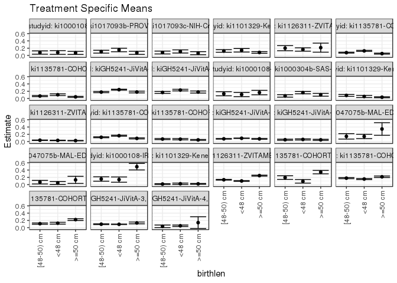

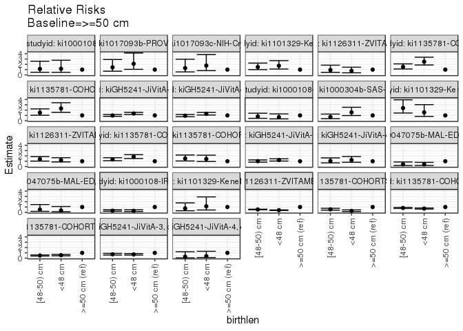

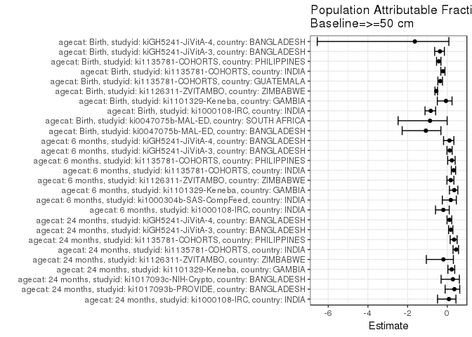

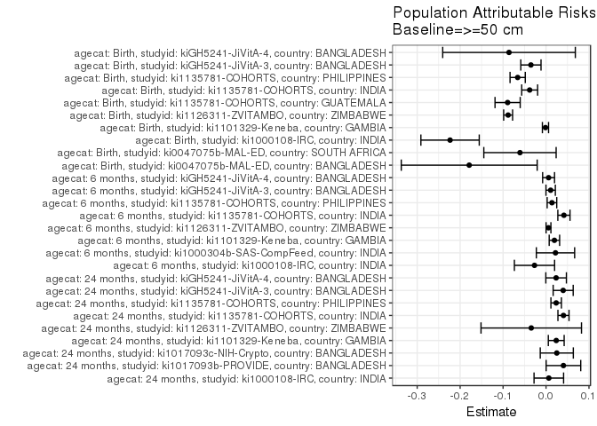

## Results Table

### Parameter: TSM

| agecat | studyid | country | intervention_level | baseline_level | estimate | ci_lower | ci_upper |
| --- | --- | --- | --- | --- | --- | --- | --- |
| Birth | ki0047075b-MAL-ED | BANGLADESH | >=50 cm | NA | 0.3448276 | 0.1714748 | 0.5181804 |
| Birth | ki0047075b-MAL-ED | BANGLADESH | <48 cm | NA | 0.1406250 | 0.0802762 | 0.2009738 |
| Birth | ki0047075b-MAL-ED | BANGLADESH | [48-50) cm | NA | 0.1428571 | 0.0678696 | 0.2178447 |
| Birth | ki0047075b-MAL-ED | SOUTH AFRICA | >=50 cm | NA | 0.1304348 | 0.0329223 | 0.2279473 |
| Birth | ki0047075b-MAL-ED | SOUTH AFRICA | <48 cm | NA | 0.0458716 | 0.0065208 | 0.0852223 |
| Birth | ki0047075b-MAL-ED | SOUTH AFRICA | [48-50) cm | NA | 0.0679612 | 0.0192621 | 0.1166602 |
| Birth | ki1000108-IRC | INDIA | >=50 cm | NA | 0.4916667 | 0.4020887 | 0.5812446 |
| Birth | ki1000108-IRC | INDIA | <48 cm | NA | 0.1379310 | 0.0653665 | 0.2104956 |
| Birth | ki1000108-IRC | INDIA | [48-50) cm | NA | 0.1544118 | 0.0935937 | 0.2152298 |
| Birth | ki1101329-Keneba | GAMBIA | >=50 cm | NA | 0.0209790 | 0.0104706 | 0.0314874 |
| Birth | ki1101329-Keneba | GAMBIA | <48 cm | NA | 0.0239044 | 0.0050006 | 0.0428082 |
| Birth | ki1101329-Keneba | GAMBIA | [48-50) cm | NA | 0.0153173 | 0.0040536 | 0.0265810 |
| Birth | ki1126311-ZVITAMBO | ZIMBABWE | >=50 cm | NA | 0.2477477 | 0.2343621 | 0.2611334 |
| Birth | ki1126311-ZVITAMBO | ZIMBABWE | <48 cm | NA | 0.1002472 | 0.0904916 | 0.1100027 |
| Birth | ki1126311-ZVITAMBO | ZIMBABWE | [48-50) cm | NA | 0.1335480 | 0.1243715 | 0.1427246 |
| Birth | ki1135781-COHORTS | GUATEMALA | >=50 cm | NA | 0.3434343 | 0.2966340 | 0.3902347 |
| Birth | ki1135781-COHORTS | GUATEMALA | <48 cm | NA | 0.0909091 | 0.0418346 | 0.1399836 |
| Birth | ki1135781-COHORTS | GUATEMALA | [48-50) cm | NA | 0.1929825 | 0.1417236 | 0.2442413 |
| Birth | ki1135781-COHORTS | INDIA | >=50 cm | NA | 0.2150997 | 0.1936052 | 0.2365942 |
| Birth | ki1135781-COHORTS | INDIA | <48 cm | NA | 0.1537808 | 0.1392070 | 0.1683546 |
| Birth | ki1135781-COHORTS | INDIA | [48-50) cm | NA | 0.1774127 | 0.1622381 | 0.1925873 |
| Birth | ki1135781-COHORTS | PHILIPPINES | >=50 cm | NA | 0.2216216 | 0.1971838 | 0.2460595 |
| Birth | ki1135781-COHORTS | PHILIPPINES | <48 cm | NA | 0.1228879 | 0.0976638 | 0.1481119 |
| Birth | ki1135781-COHORTS | PHILIPPINES | [48-50) cm | NA | 0.1098418 | 0.0916712 | 0.1280124 |
| Birth | kiGH5241-JiVitA-3 | BANGLADESH | >=50 cm | NA | 0.1310782 | 0.1062832 | 0.1558733 |
| Birth | kiGH5241-JiVitA-3 | BANGLADESH | <48 cm | NA | 0.0927934 | 0.0865675 | 0.0990193 |
| Birth | kiGH5241-JiVitA-3 | BANGLADESH | [48-50) cm | NA | 0.0955781 | 0.0859383 | 0.1052179 |
| Birth | kiGH5241-JiVitA-4 | BANGLADESH | >=50 cm | NA | 0.1388889 | -0.0232300 | 0.3010078 |
| Birth | kiGH5241-JiVitA-4 | BANGLADESH | <48 cm | NA | 0.0521739 | 0.0314379 | 0.0729099 |
| Birth | kiGH5241-JiVitA-4 | BANGLADESH | [48-50) cm | NA | 0.0374332 | 0.0020896 | 0.0727768 |

[output cut: 51 more lines]

### Parameter: E(Y)

| agecat | studyid | country | intervention_level | baseline_level | estimate | ci_lower | ci_upper |
| --- | --- | --- | --- | --- | --- | --- | --- |
| Birth | ki0047075b-MAL-ED | BANGLADESH | NA | NA | 0.1659751 | 0.1189041 | 0.2130461 |
| Birth | ki0047075b-MAL-ED | SOUTH AFRICA | NA | NA | 0.0697674 | 0.0386213 | 0.1009135 |
| Birth | ki1000108-IRC | INDIA | NA | NA | 0.2682216 | 0.2212677 | 0.3151755 |
| Birth | ki1101329-Keneba | GAMBIA | NA | NA | 0.0196767 | 0.0124580 | 0.0268954 |
| Birth | ki1126311-ZVITAMBO | ZIMBABWE | NA | NA | 0.1594921 | 0.1531776 | 0.1658066 |
| Birth | ki1135781-COHORTS | GUATEMALA | NA | NA | 0.2539683 | 0.2229196 | 0.2850169 |
| Birth | ki1135781-COHORTS | INDIA | NA | NA | 0.1769740 | 0.1674681 | 0.1864799 |
| Birth | ki1135781-COHORTS | PHILIPPINES | NA | NA | 0.1555709 | 0.1423748 | 0.1687670 |
| Birth | kiGH5241-JiVitA-3 | BANGLADESH | NA | NA | 0.0958686 | 0.0906699 | 0.1010673 |
| Birth | kiGH5241-JiVitA-4 | BANGLADESH | NA | NA | 0.0527086 | 0.0336587 | 0.0717585 |
| 6 months | ki1000108-IRC | INDIA | NA | NA | 0.1362468 | 0.1021125 | 0.1703810 |
| 6 months | ki1000304b-SAS-CompFeed | INDIA | NA | NA | 0.1240545 | 0.0993302 | 0.1487787 |
| 6 months | ki1101329-Keneba | GAMBIA | NA | NA | 0.0549369 | 0.0427642 | 0.0671096 |
| 6 months | ki1126311-ZVITAMBO | ZIMBABWE | NA | NA | 0.0320489 | 0.0282307 | 0.0358672 |
| 6 months | ki1135781-COHORTS | INDIA | NA | NA | 0.1289375 | 0.1205453 | 0.1373297 |
| 6 months | ki1135781-COHORTS | PHILIPPINES | NA | NA | 0.0592812 | 0.0503704 | 0.0681920 |
| 6 months | kiGH5241-JiVitA-3 | BANGLADESH | NA | NA | 0.0846506 | 0.0797924 | 0.0895088 |
| 6 months | kiGH5241-JiVitA-4 | BANGLADESH | NA | NA | 0.0531809 | 0.0435210 | 0.0628408 |
| 24 months | ki1000108-IRC | INDIA | NA | NA | 0.0769231 | 0.0504429 | 0.1034032 |
| 24 months | ki1017093b-PROVIDE | BANGLADESH | NA | NA | 0.1124567 | 0.0866788 | 0.1382347 |
| 24 months | ki1017093c-NIH-Crypto | BANGLADESH | NA | NA | 0.0875486 | 0.0630907 | 0.1120065 |
| 24 months | ki1101329-Keneba | GAMBIA | NA | NA | 0.1060038 | 0.0875152 | 0.1244923 |
| 24 months | ki1126311-ZVITAMBO | ZIMBABWE | NA | NA | 0.1798561 | 0.1429491 | 0.2167631 |
| 24 months | ki1135781-COHORTS | INDIA | NA | NA | 0.0908513 | 0.0826532 | 0.0990495 |
| 24 months | ki1135781-COHORTS | PHILIPPINES | NA | NA | 0.0682747 | 0.0582774 | 0.0782720 |
| 24 months | kiGH5241-JiVitA-3 | BANGLADESH | NA | NA | 0.2183007 | 0.2083024 | 0.2282989 |
| 24 months | kiGH5241-JiVitA-4 | BANGLADESH | NA | NA | 0.2013085 | 0.1867334 | 0.2158836 |

### Parameter: RR

| agecat | studyid | country | intervention_level | baseline_level | estimate | ci_lower | ci_upper |
| --- | --- | --- | --- | --- | --- | --- | --- |
| Birth | ki0047075b-MAL-ED | BANGLADESH | >=50 cm | >=50 cm | 1.0000000 | 1.0000000 | 1.0000000 |
| Birth | ki0047075b-MAL-ED | BANGLADESH | <48 cm | >=50 cm | 0.4078125 | 0.2105715 | 0.7898080 |
| Birth | ki0047075b-MAL-ED | BANGLADESH | [48-50) cm | >=50 cm | 0.4142857 | 0.2002844 | 0.8569447 |
| Birth | ki0047075b-MAL-ED | SOUTH AFRICA | >=50 cm | >=50 cm | 1.0000000 | 1.0000000 | 1.0000000 |
| Birth | ki0047075b-MAL-ED | SOUTH AFRICA | <48 cm | >=50 cm | 0.3516820 | 0.1127118 | 1.0973137 |
| Birth | ki0047075b-MAL-ED | SOUTH AFRICA | [48-50) cm | >=50 cm | 0.5210356 | 0.1849829 | 1.4675846 |
| Birth | ki1000108-IRC | INDIA | >=50 cm | >=50 cm | 1.0000000 | 1.0000000 | 1.0000000 |
| Birth | ki1000108-IRC | INDIA | <48 cm | >=50 cm | 0.2805377 | 0.1607677 | 0.4895349 |
| Birth | ki1000108-IRC | INDIA | [48-50) cm | >=50 cm | 0.3140578 | 0.2034887 | 0.4847066 |
| Birth | ki1101329-Keneba | GAMBIA | >=50 cm | >=50 cm | 1.0000000 | 1.0000000 | 1.0000000 |
| Birth | ki1101329-Keneba | GAMBIA | <48 cm | >=50 cm | 1.1394422 | 0.4468382 | 2.9055903 |
| Birth | ki1101329-Keneba | GAMBIA | [48-50) cm | >=50 cm | 0.7301240 | 0.2999046 | 1.7775020 |
| Birth | ki1126311-ZVITAMBO | ZIMBABWE | >=50 cm | >=50 cm | 1.0000000 | 1.0000000 | 1.0000000 |
| Birth | ki1126311-ZVITAMBO | ZIMBABWE | <48 cm | >=50 cm | 0.4046341 | 0.3620114 | 0.4522752 |
| Birth | ki1126311-ZVITAMBO | ZIMBABWE | [48-50) cm | >=50 cm | 0.5390484 | 0.4939302 | 0.5882879 |
| Birth | ki1135781-COHORTS | GUATEMALA | >=50 cm | >=50 cm | 1.0000000 | 1.0000000 | 1.0000000 |
| Birth | ki1135781-COHORTS | GUATEMALA | <48 cm | >=50 cm | 0.2647059 | 0.1516940 | 0.4619115 |
| Birth | ki1135781-COHORTS | GUATEMALA | [48-50) cm | >=50 cm | 0.5619195 | 0.4168923 | 0.7573984 |
| Birth | ki1135781-COHORTS | INDIA | >=50 cm | >=50 cm | 1.0000000 | 1.0000000 | 1.0000000 |
| Birth | ki1135781-COHORTS | INDIA | <48 cm | >=50 cm | 0.7149280 | 0.6229469 | 0.8204904 |
| Birth | ki1135781-COHORTS | INDIA | [48-50) cm | >=50 cm | 0.8247930 | 0.7231361 | 0.9407405 |
| Birth | ki1135781-COHORTS | PHILIPPINES | >=50 cm | >=50 cm | 1.0000000 | 1.0000000 | 1.0000000 |
| Birth | ki1135781-COHORTS | PHILIPPINES | <48 cm | >=50 cm | 0.5544940 | 0.4392425 | 0.6999860 |
| Birth | ki1135781-COHORTS | PHILIPPINES | [48-50) cm | >=50 cm | 0.4956278 | 0.4062697 | 0.6046399 |
| Birth | kiGH5241-JiVitA-3 | BANGLADESH | >=50 cm | >=50 cm | 1.0000000 | 1.0000000 | 1.0000000 |
| Birth | kiGH5241-JiVitA-3 | BANGLADESH | <48 cm | >=50 cm | 0.7079238 | 0.5803017 | 0.8636131 |
| Birth | kiGH5241-JiVitA-3 | BANGLADESH | [48-50) cm | >=50 cm | 0.7291682 | 0.5912094 | 0.8993197 |
| Birth | kiGH5241-JiVitA-4 | BANGLADESH | >=50 cm | >=50 cm | 1.0000000 | 1.0000000 | 1.0000000 |
| Birth | kiGH5241-JiVitA-4 | BANGLADESH | <48 cm | >=50 cm | 0.3756522 | 0.1094653 | 1.2891256 |
| Birth | kiGH5241-JiVitA-4 | BANGLADESH | [48-50) cm | >=50 cm | 0.2695187 | 0.0599227 | 1.2122333 |

[output cut: 51 more lines]

### Parameter: PAR

| agecat | studyid | country | intervention_level | baseline_level | estimate | ci_lower | ci_upper |
| --- | --- | --- | --- | --- | --- | --- | --- |
| Birth | ki0047075b-MAL-ED | BANGLADESH | >=50 cm | NA | -0.1788525 | -0.3370758 | -0.0206291 |
| Birth | ki0047075b-MAL-ED | SOUTH AFRICA | >=50 cm | NA | -0.0606673 | -0.1448580 | 0.0235233 |
| Birth | ki1000108-IRC | INDIA | >=50 cm | NA | -0.2234451 | -0.2913735 | -0.1555167 |
| Birth | ki1101329-Keneba | GAMBIA | >=50 cm | NA | -0.0013023 | -0.0084833 | 0.0058787 |
| Birth | ki1126311-ZVITAMBO | ZIMBABWE | >=50 cm | NA | -0.0882556 | -0.0986566 | -0.0778546 |
| Birth | ki1135781-COHORTS | GUATEMALA | >=50 cm | NA | -0.0894661 | -0.1187871 | -0.0601451 |
| Birth | ki1135781-COHORTS | INDIA | >=50 cm | NA | -0.0381257 | -0.0566430 | -0.0196084 |
| Birth | ki1135781-COHORTS | PHILIPPINES | >=50 cm | NA | -0.0660507 | -0.0837712 | -0.0483303 |
| Birth | kiGH5241-JiVitA-3 | BANGLADESH | >=50 cm | NA | -0.0352096 | -0.0587515 | -0.0116677 |
| Birth | kiGH5241-JiVitA-4 | BANGLADESH | >=50 cm | NA | -0.0861803 | -0.2405764 | 0.0682159 |
| 6 months | ki1000108-IRC | INDIA | >=50 cm | NA | -0.0268738 | -0.0736798 | 0.0199322 |
| 6 months | ki1000304b-SAS-CompFeed | INDIA | >=50 cm | NA | 0.0220136 | -0.0225790 | 0.0666063 |
| 6 months | ki1101329-Keneba | GAMBIA | >=50 cm | NA | 0.0194864 | 0.0073552 | 0.0316176 |
| 6 months | ki1126311-ZVITAMBO | ZIMBABWE | >=50 cm | NA | 0.0057111 | 0.0000841 | 0.0113382 |
| 6 months | ki1135781-COHORTS | INDIA | >=50 cm | NA | 0.0416538 | 0.0274825 | 0.0558251 |
| 6 months | ki1135781-COHORTS | PHILIPPINES | >=50 cm | NA | 0.0137807 | 0.0026236 | 0.0249379 |
| 6 months | kiGH5241-JiVitA-3 | BANGLADESH | >=50 cm | NA | 0.0107600 | -0.0001604 | 0.0216805 |
| 6 months | kiGH5241-JiVitA-4 | BANGLADESH | >=50 cm | NA | 0.0059511 | -0.0079145 | 0.0198168 |
| 24 months | ki1000108-IRC | INDIA | >=50 cm | NA | 0.0065005 | -0.0279054 | 0.0409065 |
| 24 months | ki1017093b-PROVIDE | BANGLADESH | >=50 cm | NA | 0.0405143 | 0.0002170 | 0.0808116 |
| 24 months | ki1017093c-NIH-Crypto | BANGLADESH | >=50 cm | NA | 0.0250486 | -0.0134555 | 0.0635528 |
| 24 months | ki1101329-Keneba | GAMBIA | >=50 cm | NA | 0.0237608 | 0.0053274 | 0.0421941 |
| 24 months | ki1126311-ZVITAMBO | ZIMBABWE | >=50 cm | NA | -0.0344296 | -0.1514299 | 0.0825707 |
| 24 months | ki1135781-COHORTS | INDIA | >=50 cm | NA | 0.0406098 | 0.0276987 | 0.0535209 |
| 24 months | ki1135781-COHORTS | PHILIPPINES | >=50 cm | NA | 0.0235820 | 0.0113708 | 0.0357932 |
| 24 months | kiGH5241-JiVitA-3 | BANGLADESH | >=50 cm | NA | 0.0399130 | 0.0165858 | 0.0632402 |
| 24 months | kiGH5241-JiVitA-4 | BANGLADESH | >=50 cm | NA | 0.0234687 | -0.0004869 | 0.0474243 |

### Parameter: PAF

| agecat | studyid | country | intervention_level | baseline_level | estimate | ci_lower | ci_upper |
| --- | --- | --- | --- | --- | --- | --- | --- |
| Birth | ki0047075b-MAL-ED | BANGLADESH | >=50 cm | NA | -1.0775862 | -2.2738111 | -0.3184525 |
| Birth | ki0047075b-MAL-ED | SOUTH AFRICA | >=50 cm | NA | -0.8695652 | -2.4787419 | -0.0047523 |
| Birth | ki1000108-IRC | INDIA | >=50 cm | NA | -0.8330616 | -1.1208325 | -0.5843377 |
| Birth | ki1101329-Keneba | GAMBIA | >=50 cm | NA | -0.0661838 | -0.5002825 | 0.2423108 |
| Birth | ki1126311-ZVITAMBO | ZIMBABWE | >=50 cm | NA | -0.5533543 | -0.6183626 | -0.4909574 |
| Birth | ki1135781-COHORTS | GUATEMALA | >=50 cm | NA | -0.3522727 | -0.4721003 | -0.2421990 |
| Birth | ki1135781-COHORTS | INDIA | >=50 cm | NA | -0.2154311 | -0.3243667 | -0.1154560 |
| Birth | ki1135781-COHORTS | PHILIPPINES | >=50 cm | NA | -0.4245700 | -0.5401908 | -0.3176288 |
| Birth | kiGH5241-JiVitA-3 | BANGLADESH | >=50 cm | NA | -0.3672695 | -0.6339594 | -0.1441079 |
| Birth | kiGH5241-JiVitA-4 | BANGLADESH | >=50 cm | NA | -1.6350309 | -6.5555927 | 0.0810267 |
| 6 months | ki1000108-IRC | INDIA | >=50 cm | NA | -0.1972434 | -0.5921885 | 0.0997348 |
| 6 months | ki1000304b-SAS-CompFeed | INDIA | >=50 cm | NA | 0.1774515 | -0.2480226 | 0.4578735 |
| 6 months | ki1101329-Keneba | GAMBIA | >=50 cm | NA | 0.3547048 | 0.1099869 | 0.5321351 |
| 6 months | ki1126311-ZVITAMBO | ZIMBABWE | >=50 cm | NA | 0.1782006 | -0.0160368 | 0.3353052 |
| 6 months | ki1135781-COHORTS | INDIA | >=50 cm | NA | 0.3230544 | 0.2056243 | 0.4231251 |
| 6 months | ki1135781-COHORTS | PHILIPPINES | >=50 cm | NA | 0.2324633 | 0.0229399 | 0.3970560 |
| 6 months | kiGH5241-JiVitA-3 | BANGLADESH | >=50 cm | NA | 0.1271109 | -0.0126090 | 0.2475522 |
| 6 months | kiGH5241-JiVitA-4 | BANGLADESH | >=50 cm | NA | 0.1119034 | -0.1869392 | 0.3355046 |
| 24 months | ki1000108-IRC | INDIA | >=50 cm | NA | 0.0845070 | -0.4909232 | 0.4378467 |
| 24 months | ki1017093b-PROVIDE | BANGLADESH | >=50 cm | NA | 0.3602656 | -0.1060831 | 0.6299916 |
| 24 months | ki1017093c-NIH-Crypto | BANGLADESH | >=50 cm | NA | 0.2861111 | -0.3102198 | 0.6110291 |
| 24 months | ki1101329-Keneba | GAMBIA | >=50 cm | NA | 0.2241502 | 0.0337514 | 0.3770310 |
| 24 months | ki1126311-ZVITAMBO | ZIMBABWE | >=50 cm | NA | -0.1914286 | -1.0558290 | 0.3095233 |
| 24 months | ki1135781-COHORTS | INDIA | >=50 cm | NA | 0.4469917 | 0.2916230 | 0.5682832 |
| 24 months | ki1135781-COHORTS | PHILIPPINES | >=50 cm | NA | 0.3453986 | 0.1483370 | 0.4968632 |
| 24 months | kiGH5241-JiVitA-3 | BANGLADESH | >=50 cm | NA | 0.1828350 | 0.0695836 | 0.2823014 |
| 24 months | kiGH5241-JiVitA-4 | BANGLADESH | >=50 cm | NA | 0.1165805 | -0.0109438 | 0.2280185 |